# Statistica Medica — Corrado Lanera – Statistica Medica


# Statistica Medica

Analisi esplorativa e statistiche descrittive

Corrado Lanera

[Unità di Biostatistica, Epidemiologia e Salute Pubblica](https://www.unipd-ubep.it/), Università di Padova

15 novembre 2026

## Cosa faremo

Prima di tutto richiameremo alcuni simboli, notazioni, oggetti “matematici” che ci potranno tornare utili lungo la trattazione dell’intero corso.

Andremo quindi a identificare quali sono gli **oggetti** che ci interessa analizzare, e di che **tipologie** possono essere.

Quindi vedremo come **localizzarli**; ovvero, come (numericamente) avere un’idea di dove si *collochino* (rispetto a un dato riferimento o misura), questo grazie all’individuazione di uno o più **punti di riferimento** (detti **centrali**) e una misura di quanto gli altri punti di interesse siano **più o meno distanti** da questi (**variabilità**).

Poiché **guardare** numeri, a volte, può essere poco informativo, o immediato, ci occuperemo di rappresentare i nostri dati **graficamente**, individuando a seconda del tipo, quantità e interesse, il grafico più opportuno tra quelli base, imparando anche a *leggere* cosa rappresentano.

## Riconoscimenti

- Le diapositive proposte sono state prodotte a partire anche da materiale generato da/con le seguenti persone gravitanti attorno all’UBEP*:
  - Danila Azzolina
  - Dario Gregori
  - Giulia Lorenzoni
  - Honoria Ocagli
  - Ileana Baldi
  - Luca Vedovelli
  - Matteo Martinato
  - Paola Berchialla

* In ordine alfabetico.

> Un ringraziamento speciale a Cristiana Vettori per l’aiuto e il supporto logistico e amministrativo che mi è stato offerto.

## **Panoramica**

**Oggetti in gioco**

**Localizzazione**

**Rappresentazione**

## **Oggetti in gioco**

**Notazioni di base**

**unità statistiche e tabelle ordinate**

**tipologie di dati**

## Notazioni: Sommatoria

Sia $X$ un insieme di $N$ numeri: indichiamo con $x_i$ l’i-esimo elemento di $X$ (per $i = 1$, $x_1$ è il primo).

Con il simbolo $\Sigma$ (Sigma maiuscola, la “S” greca) scriviamo

$$\sum_{i = 1}^N x_i = x_1 + x_2 + \cdots + x_{N-1} + x_{N}$$

la somma di tutti gli $x_i$, che leggiamo “Sommatoria per i che va da 1 a N degli x-con-i”.

Gli indici possono essere anche codici, per esempio gli id dei pazienti in un insieme $I$ (con $R43$ id di un paziente, $x_{R43}$ è il suo peso). Allora scriviamo

$$\sum_{i\in I} x_i$$

e leggiamo “Sommatoria per gli i in I degli x-con-i”: la somma dei pesi di tutti i pazienti con id in $I$.

## Esempio sommatoria

Per esempio considerando

| I | age |
| --- | --- |
| 1 | 55.1 |
| 2 | 62.9 |
| 3 | 53.1 |
| 4 | 76.3 |
| 5 | 64.2 |
| 6 | 53.3 |

Possiamo scrivere la somma di tutte le età

```
55.1 + 62.9 + 53.1 + 76.3 + 64.2 + 53.3
```

come $\sum_{i\in I} age_i =$ 364.9.

## Una tabella disordinata

Quattro pazienti, con la pressione misurata in due giorni, registrati in un foglio di calcolo come capita spesso:

| Paziente | M | F | Età | Pressione_g1 | Pressione_g2 |
| --- | --- | --- | --- | --- | --- |
| P01 |  | X | 54 | 130/85 | 125/80 |
| P02 | X |  | 61 | 145/95 | 140/90 |
| P03 |  | X | 47 | 120/80 | 120/75 |
| P04 | X |  | 70 | 150/90 | 155/95 |

Pressione in mmHg; `_g1` e `_g2`: primo e secondo giorno di rilevazione.

- Quante sono le righe? E quante le misurazioni della pressione?
- Qual è l’**unità statistica**?
- Quante e quali sono le **variabili**?

## Dati ordinati

Una tabella è **ordinata** (in inglese *tidy*) quando rispetta tre regole:

1. Ogni **variabile** è una **colonna**, e ogni colonna è una variabile.
2. Ogni **osservazione** (l’unità statistica) è una **riga**, e ogni riga è un’osservazione.
3. Ogni **valore** è una **cella**, e ogni cella contiene un solo valore.

La tabella di prima le viola tutte e tre:

1. il **sesso** occupa due colonne (M e F), e così la **pressione**; inoltre il **giorno** della rilevazione, che è un’altra variabile, sta nascosto nel nome delle colonne (`_g1`, `_g2`);
2. ogni riga contiene **due misurazioni**, cioè due osservazioni, una per giorno;
3. **«130/85»** sono due valori in una cella: pressione sistolica e diastolica.

## La stessa tabella, ordinata

| Paziente | Sesso | Età (anni) | Giorno | PAS (mmHg) | PAD (mmHg) |
| --- | --- | --- | --- | --- | --- |
| P01 | F | 54 | 1 | 130 | 85 |
| P01 | F | 54 | 2 | 125 | 80 |
| P02 | M | 61 | 1 | 145 | 95 |
| P02 | M | 61 | 2 | 140 | 90 |
| P03 | F | 47 | 1 | 120 | 80 |
| P03 | F | 47 | 2 | 120 | 75 |
| P04 | M | 70 | 1 | 150 | 90 |
| P04 | M | 70 | 2 | 155 | 95 |

PAS e PAD: pressione arteriosa sistolica e diastolica.

- **8 righe**, una per misurazione. Ogni riga è un’**unità statistica**, ciò su cui si misura: qui la misurazione (un paziente in un giorno), non il paziente.
- **Sesso** ed **età** si ripetono: sono caratteristiche del paziente, uguali in tutte le sue misurazioni.

## Un esempio reale

Le prime 10 delle 200 righe della coorte EPIC-Norfolk, che useremo negli esempi che seguono: ogni riga è un partecipante (l’unità statistica), ogni colonna una variabile.

| id | gender | age | att.fisica | sigarette | bmi | sbp | dbp | cole.tot | mag | farmaci |
| --- | --- | --- | --- | --- | --- | --- | --- | --- | --- | --- |
| 1 | M | 55.1 | Mai | 1 | 30.4 | 151.0 | 108.0 | 5.2 | 425.5 | No |
| 2 | M | 62.9 | 1-2 volte a sett. | 2 | 42.6 | 140.1 | 103.9 | 4.6 | 312.6 | Statine |
| 3 | M | 53.1 | 3 Volte a sett. | 2 | 41.6 | 145.2 | 120.6 | 4.8 | 426.8 | Statine |
| 4 | M | 76.3 | Mai | 2 | 23.3 | 126.9 | 114.0 | 8.4 | 422.7 | fibrati |
| 5 | M | 64.2 | 3 Volte a sett. | 1 | 32.9 | 151.6 | 116.0 | 7.7 | 281.1 | No |
| 6 | M | 53.3 | Mai | 1 | 31.7 | 167.4 | 100.7 | 6.6 | 318.2 | No |
| 7 | M | 65.7 | 3 Volte a sett. | 1 | 26.4 | 160.0 | 101.5 | 6.0 | 424.5 | No |
| 8 | M | 68.1 | 3 Volte a sett. | 0 | 31.4 | 125.0 | 101.0 | 5.3 | 327.3 | Statine |
| 9 | M | 66.6 | 3 Volte a sett. | 0 | 24.9 | 110.1 | 109.3 | 5.1 | 203.7 | No |
| 10 | M | 58.2 | 1-2 volte a sett. | 2 | 30.5 | 138.0 | 106.4 | 6.7 | 412.4 | No |

## Tipologie di dati

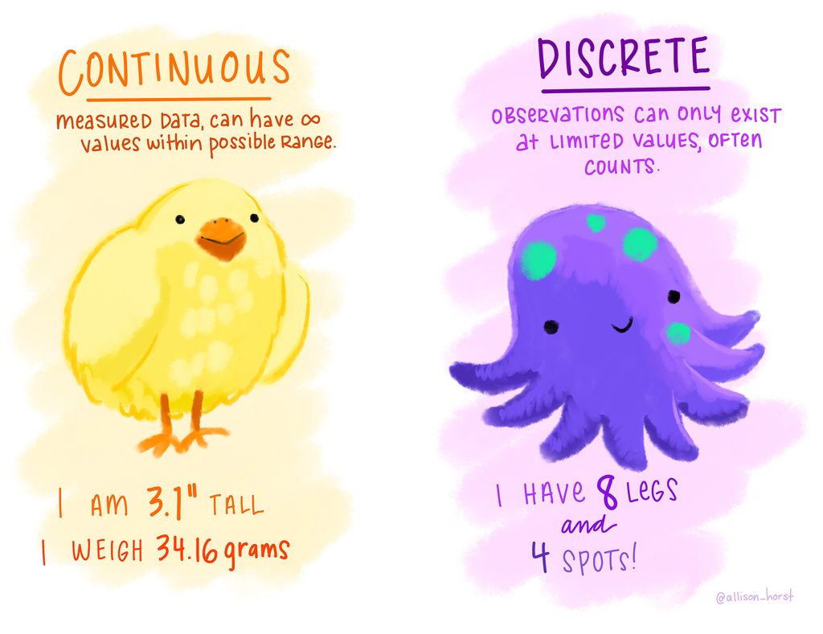

## Tipologie di dati

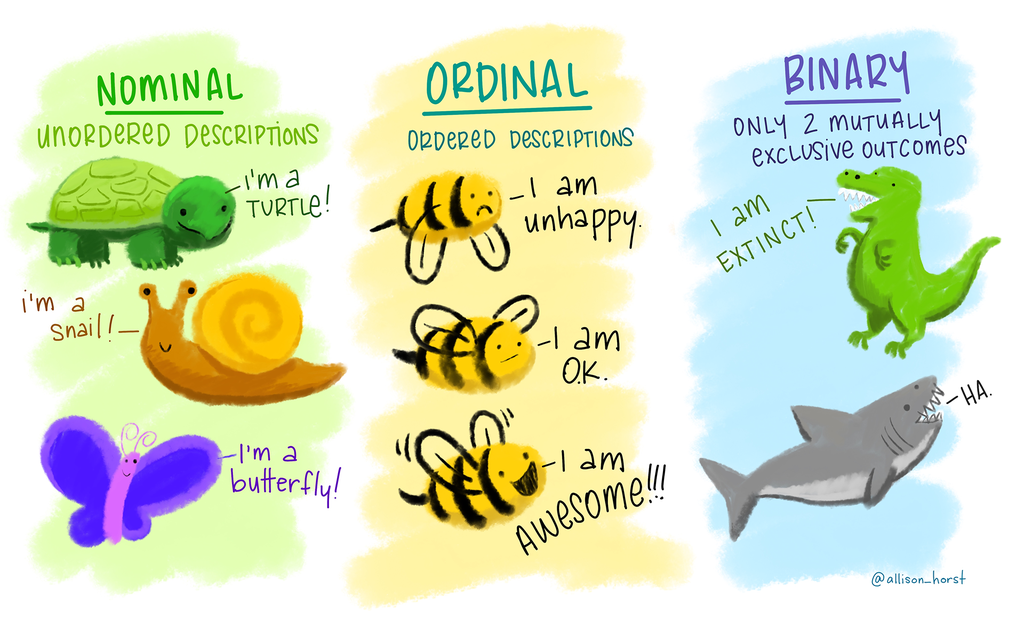

## Tipologie di dati: in sintesi

- **Continue**: possono assumere qualunque valore in un intervallo; nascono da una **misura** (età, peso, pressione, colesterolo).
- **Discrete**: possono assumere solo valori separati.
  - **nominali**: categorie senza un ordine (gruppo sanguigno, farmaco assunto);
  - **ordinali**: categorie con un ordine (stadio del tumore; attività fisica: mai, 1-2 volte, 3 volte a settimana);
  - **dicotomiche** (o binarie): solo due categorie, che si escludono a vicenda (fumatore: sì/no);
  - **cardinali**: **conteggi**, rispondono a «quanti?» (numero di figli, ricoveri nell’ultimo anno, sigarette al giorno).

**Cardinale non vuol dire numerica**: 130 mmHg è un numero, ma non conta niente: è una misura, quindi continua. Una cardinale conta qualcosa: 3 ricoveri sono uno in più di 2, mentre fra «mai» e «1-2 volte» (ordinale) c’è solo un ordine.

## Sondaggio

Per me: [Tipi di variabile](https://app.wooclap.com/events/STATMEDTYPE/0)

Per voi:

[figure not shown]

bit.ly/statmed-sondaggio-tipi-variabili

## Mappa: Oggetti in gioco

- Mappa
- Indice

```
%%{init: {"htmlLabels": false, "flowchart": {"padding": 12, "wrappingWidth": 320}, "themeVariables": {"fontFamily": "Arial, Helvetica, sans-serif"}}}%%
flowchart TB
  n_notazione_con_indici["Indici (x_i)"]:::cur
  n_sommatoria["Sommatoria Σ"]:::cur
  n_appartenenza_insiemistica["Appartenenza (∈)"]:::cur
  n_unita_statistica["Unità statistica"]:::cur
  n_variabile["Variabile"]:::cur
  n_dati_ordinati["Dati ordinati"]:::cur
  n_tipo_di_variabile["Tipo di variabile"]:::cur
  n_variabile_continua["Continua"]:::cur
  n_variabile_discreta["Discreta"]:::cur
  n_variabile_cardinale["Cardinale"]:::cur
  n_variabile_nominale["Nominale"]:::cur
  n_variabile_ordinale["Ordinale"]:::cur
  n_variabile_dicotomica["Dicotomica"]:::cur
  n_notazione_con_indici --> n_sommatoria
  n_tipo_di_variabile --> n_variabile_continua
  n_tipo_di_variabile --> n_variabile_discreta
  n_unita_statistica --> n_variabile
  n_variabile --> n_dati_ordinati
  n_variabile --> n_tipo_di_variabile
  n_variabile_continua --> n_variabile_cardinale
  n_variabile_discreta --> n_variabile_cardinale
  n_variabile_discreta --> n_variabile_dicotomica
  n_variabile_discreta --> n_variabile_nominale
  n_variabile_discreta --> n_variabile_ordinale
  classDef cur fill:#e6f0fa,stroke:#035AA6,color:#000000
  classDef prev fill:#f4f4f4,stroke:#9a9a9a,color:#555555,stroke-dasharray:4 3
  classDef opt fill:#ffffff,stroke:#035AA6,color:#555555,stroke-dasharray:2 2
```

Ogni freccia va da un concetto a quelli che lo usano. In grigio i concetti delle sezioni o dei deck precedenti (con il numero del deck).

- Indici (x_i)
- Sommatoria Σ
- Appartenenza (∈)
- Unità statistica
- Variabile
- Dati ordinati
- Tipo di variabile
- Continua
- Discreta
- Cardinale
- Nominale
- Ordinale
- Dicotomica

## **Localizzazione (dati continui)**

**Misure di centralità**

**Misure di variabilità (e confrontabilità)**

**Percentili**

**Accorpamenti, e misure ponderate**

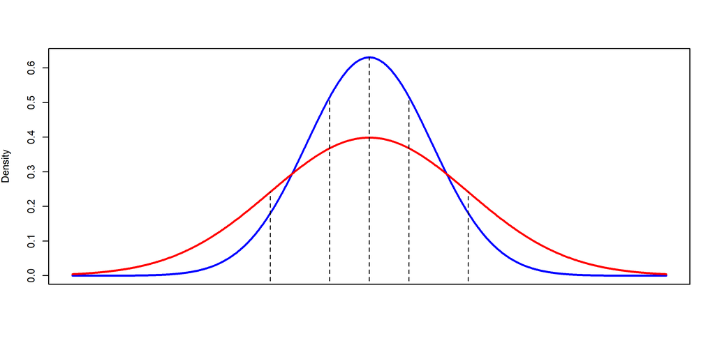

## Misure di centralità: media

Data una variabile $x$, misurata su $n$ soggetti, la media aritmetica campionaria è pari a
$$\bar{x} = \frac{1}{n}\sum_{i=1}^n x_i$$

È molto sensibile ai valori estremi: se ce ne sono non è una buona misura di centralità.

> Es.: se in questa stanza entra Elon Musk, quale sarebbe la media del saldo dei conti in banca dei presenti (ma anche di tutta Rovigo…)? Sarebbe una buona misura di *centralità* per tale distribuzione di valori?

## Media (*estremamente* sensibile)

Riprendendo le età del nostro sotto-campione di soggetti, la loro media è

| I | age |
| --- | --- |
| 1 | 55.1 |
| 2 | 62.9 |
| 3 | 53.1 |
| 4 | 76.3 |
| 5 | 64.2 |
| 6 | 53.3 |

$\frac{1}{6}\sum_{i=1}^6 age_i =$ **60.82**

La media è molto sensibile ai dati estremi: sostituendo, per esempio, anche solamente il primo valore (55.1) con 5.51 (ipotizzando un errore di inserimento), la media cambia sensibilmente e diviene **52.55**.

## Misure di centralità: mediana

Ordiniamo ora le $n$ osservazioni. La mediana campionaria è

- la $(\frac{n+1}{2})$-ma osservazione se $n$ è dispari (ovvero, **ha un centro**) > Se prendo $k=n/2$ ottengo una “posizione” con la virgola, quindi prendo la prima (intera) successiva.
- la media aritmetica della $(\frac{n}{2})$-ma e la $(\frac{n}{2}+1)$-ma osservazione se $n$ è pari (ovvero, **non ha un centro**) > Se prendo $k=n/2$ ottengo un numero intero, e prendo allora la media tra la $k$-esima e la $k+1$-esima osservazione

## Mediana (n pari)

Nel nostro esempio

|  | I | age |
| --- | --- | --- |
| 1 | 3 | 53.1 |
| 2 | 6 | 53.3 |
| 3 | 1 | 55.1 |
| 4 | 2 | 62.9 |
| 5 | 5 | 64.2 |
| 6 | 4 | 76.3 |

Siccome $n$ è pari (è 6), la mediana è la media tra la 3a e 4a osservazione (ordinate!)
$$\mbox{Mediana} = \frac{55.1 + 62.9}{2} = 59$$
E anche modificando il primo valore (55.1) con 5.51, la mediana cambia molto poco, diventando **58.1** (invece di 59).

## Mediana (n dispari)

|  | I | age |
| --- | --- | --- |
| 1 | 3 | 53.1 |
| 2 | 6 | 53.3 |
| 3 | 1 | 55.1 |
| 4 | 2 | 62.9 |
| 5 | 5 | 64.2 |
| 6 | 7 | 65.7 |
| 7 | 4 | 76.3 |

Nel caso in cui $n$ sia dispari (prendiamo per esempio $n = 7$), prendiamo direttamente il valore centrale (in posizione $4 = (7+1)/2$), ovvero **62.9**.

## Media o mediana?

Con dati a **coda lunga** (degenze, trigliceridi, redditi) pochi valori molto grandi **tirano la media** verso la coda; la mediana no.

In questi casi la **media** non descrive il valore tipico, e si descrivono i dati con la **mediana** (e con i quartili, che vedremo più avanti).

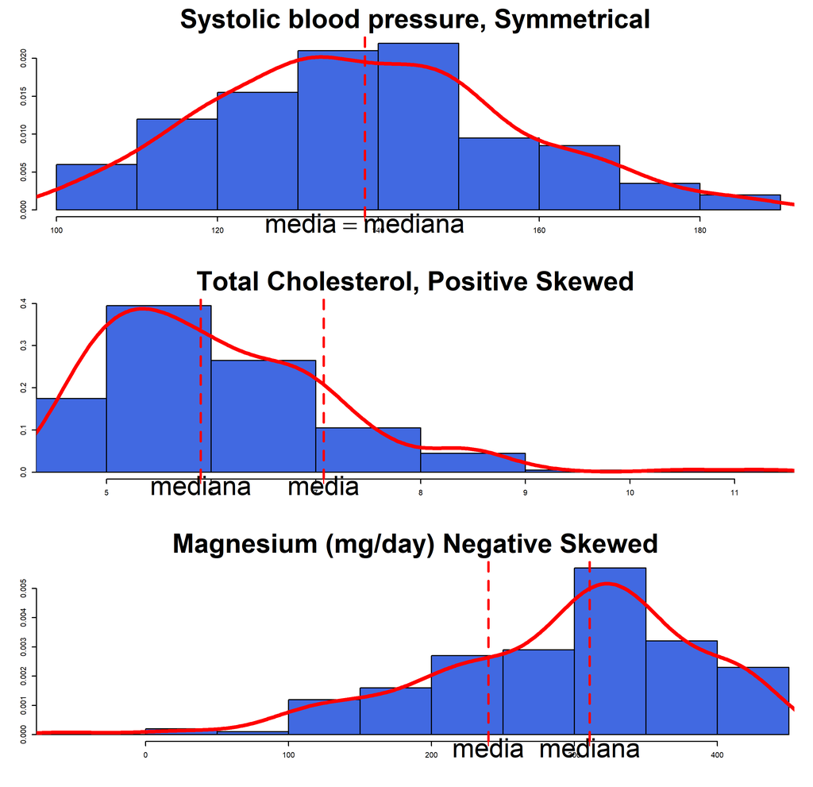

## Misure di centralità: Moda

le mode sono ciascuno dei valori che si osservano con **massima frequenza**.

Sigarette al giorno

| sigarette | n |
| --- | --- |
| 0 | 51 |
| 1 | 62 |
| 2 | 46 |
| 3 | 14 |
| 4 | 17 |
| 5 | 7 |
| 6 | 2 |
| 7 | 1 |

Moda di sigarette fumate al giorno

| sigarette | n |
| --- | --- |
| 1 | 62 |

> NOTA: una distribuzione può essere *unimodale*, *bimodale*, *trimodale*, …

## Misure di variabilità

Si considerino due campioni di misurazioni del colesterolo eseguite con due tecniche, una autoanalitica e l’altra microenzimatica:

| autoanalitica | microenzimatica |
| --- | --- |
| 177 | 192 |
| 193 | 197 |
| 195 | 200 |
| 209 | 202 |
| 226 | 209 |

Le medie campionarie (nonostante la differenza di variabilità) restano identiche:

| autoanalitica | microenzimatica |
| --- | --- |
| 200 | 200 |

## Misure di variabilità: range (massimale)

Il **range** massimale è la differenza tra il valore massimo osservato e quello minimo.

Simbolicamente:
$$range = max(x_i)-min(x_i)$$

| autoanalitica | microenzimatica |
| --- | --- |
| 49 | 17 |

È molto semplice da calcolare ma molto sensibile ai valori estremi.

> Dipende dall’ampiezza campionaria $n$, e **tende ad aumentare** all’aumentare di $N$! (un campione più grande della stessa popolazione avrà estremi più lontani e non più vicini)

## Misure di variabilità: varianza campionaria

La varianza campionaria è definita come

$$s^2 = \frac{\sum_{i=1}^n (x_i-\bar{x})^2}{n-1}$$

Questa è una misura di quanto, in media, sono grandi i **quadrati** degli scarti dei dati dalla loro media.

È un valore non confrontabile con i dati stessi in quanto con un’altra unità di misura. Si definisce quindi la **deviazione standard** campionaria, come

$$s = \sqrt{s^2} = \sqrt{\frac{\sum_{i=1}^n (x_i-\bar{x})^2}{n-1}}$$

> Si noti che $\sum_{i=1}^n (x_i-\bar{x}) = 0$

## Varianza campionaria: esempio

| autoanalitica | microenzimatica |
| --- | --- |
| 177 | 192 |
| 193 | 197 |
| 195 | 200 |
| 209 | 202 |
| 226 | 209 |

Medie:

| autoanalitica | microenzimatica |
| --- | --- |
| 200 | 200 |

- Autoanalitica
- Microenzimatica

$\begin{split}s^2& = \frac{1}{5-1}[(177-200)^2 + (193-200)^2 + (195-200)^2\\&\qquad + (209-200)^2 + (226-200)^2]\\& = \frac{(-23)^2 + (-7)^2 + (-5)^2 + 9^2 + 26^2}{4}\\& = \frac{529 + 49 + 25 + 81 + 676}{4}\\& = \frac{1360}{4} = 340\ (\text{mg/dl})^2\end{split}$

$s = \sqrt{340\ (\text{mg/dl})^2} = 18.4\ \text{mg/dl}$

$\begin{split}s^2& = \frac{(192-200)^2 + \ldots + (209-200)^2}{4}\\& = \frac{158}{4} = 39.5\ (\text{mg/dl})^2\end{split}$

$s = \sqrt{39.5\ (\text{mg/dl})^2} = 6.3\ \text{mg/dl}$

## Varianza (formula alternativa)

Sui libri, o da chi vi ha insegnato statistica prima, potreste trovare anche questa formula
$$s^2=\frac{(\sum_{i=1}^n x_i^2) - n\bar{x}^2}{n-1}$$

Per la tecnica autoanalitica si ha
$$\sum_{i=1}^5 x_i^2 = 177^2+\ldots+226^2=201360$$
$$s^2 = \frac{201360 - 5 \times 200^2}{4}= 1360/4=340$$

Il risultato è lo stesso; cambia il lavoro alla calcolatrice. Sui 5 valori dell’autoanalitica:

|  | Da annotare | Tasti | Sequenza sulla calcolatrice |
| --- | --- | --- | --- |
| Definizione | 10 (5 scarti, 5 quadrati) | 58 | `(177−200)x² + … + (226−200)x² = ÷ 4 =` |
| Formula alternativa | 5 (i quadrati) | 35 | `177x² + … + 226x² − 5 × 200x² = ÷ 4 =` |

Sembra conveniente: meno tasti e meno numeri da annotare. Ma…

## Formula alternativa: non usatela

Se l’ultimo valore fosse 228 invece di 226, la media sarebbe **200.4**, e la varianza vera **366.8**. Arrotondando la media a 200:

|  | Calcolo con la media arrotondata | $s^2$ |
| --- | --- | --- |
| Definizione | $\dfrac{(-23)^2 + (-7)^2 + (-5)^2 + 9^2 + 28^2}{4} = \dfrac{1468}{4}$ | **367** |
| Formula alternativa | $\dfrac{202268 - 5 \times 200^2}{4} = \dfrac{2268}{4}$ | **567** |

Con la definizione, arrotondare la media sposta di poco il risultato; con la formula alternativa lo stravolge, perché sottrae due numeri grandi e quasi uguali.

**Se trovate questa formula, o vi suggeriscono di usarla, NON usatela: usate sempre la definizione.**

## Misure di variabilità: coefficiente di variazione

Sebbene la deviazione standard sia della stessa unità di misura dei dati, non permette di confrontare tra loro le variabilità di variabili con unità di misura differenti.

Il **coefficiente di variazione** $CV$ è definito come
$$CV = \frac{100s}{\bar{x}}$$
È una misura adimensionale, e quindi utilizzabile anche per confrontare variabili di natura differente (purché positive e con zero assoluto). È anche insensibile alla scala, ovvero a trasformazioni del tipo $cx$

## CV (non-effetto scala)

I valori di Colesterolo raccolti dai 200 pazienti del database Epic sono i seguenti:

```
5.2, 4.6, 4.8, 8.4, 7.7, 6.6, 6, 5.3, 5.1, 6.7, 7.3, 5.1, 5, 5.4, 6.4,
6.6, 4.7, 5.7, 4.8, 5.9, 5.2, 5.6, 7.2, 5.9, 6.1, 5.5, 4.8, 7.6, 4.8, 5.4,
5.9, 5.6, 6.9, 6.9, 5, 9.1, 5.8, 5.5, 7.4, 6.4, 6.2, 7.2, 4.9, 6.7, 6.8,
5.4, 7.1, 5.9, 5.9, 5.3, 7, 6.8, 6.1, 5.5, 6.3, 5.3, 6.1, 5.6, 8, 4.9,
6, 6.7, 5.1, 6.8, 4.8, 4.9, 4.7, 5.8, 5.9, 6.2, 4.8, 5, 10.5, 6.9, 6,
5.4, 6.8, 5.4, 5.3, 5.5, 5.5, 7.4, 6.4, 6.9, 5.2, 6.2, 6.4, 4.9, 8.6, 4.6,
5.2, 5.7, 6, 8.5, 5.4, 5.1, 8.4, 6, 6.7, 5.4, 7.3, 6.4, 7.1, 5.3, 7.1,
4.9, 5.1, 7, 4.7, 6.5, 8.7, 7, 6.2, 5.5, 5.7, 4.6, 5.1, 7, 5.4, 6.3,
6.3, 5.9, 5.4, 4.6, 5.8, 5.5, 6.2, 7.6, 6.4, 5.9, 7.7, 6.4, 8.4, 6.9, 5.2,
5.8, 4.7, 4.8, 7.5, 6, 8.5, 8.4, 4.9, 4.8, 5, 6.7, 7.3, 5.4, 6.7, 4.7,
5.5, 6.8, 11.3, 4.7, 5.8, 5.4, 5.4, 5.8, 5.2, 7, 6.4, 6.8, 7.5, 5, 6.3,
6.6, 5.6, 5.7, 5.6, 7.1, 5.1, 5, 4.6, 5.2, 4.9, 6.7, 7.1, 6.6, 5.3, 6,
4.7, 7.1, 5.3, 5.8, 6.7, 6.1, 7.9, 6.2, 5.7, 6.1, 5.1, 5.7, 5.4, 5.2, 6.7,
6, 4.6, 4.7, 8.3, 5.2
```

Partendo dai dati così espressi in mmol/L: $CV = 1.12/6.07 \times 100 \simeq 18\%$

e per gli stessi valori espressi in mg/dl (massa molare colesterolo: 386.65 g/mol) abbiamo:
$$CV = 43.35/234.83 \times 100 \simeq 18\%$$

## Sondaggio

Per me: [Localizzazione](https://app.wooclap.com/events/STATMEDLOCALIZZAZIONE/0)

Per voi:

[figure not shown]

bit.ly/statmed-sondaggio-localizzazione

## Domande fin qui?

## Percentili

Il **percentile** $p$-esimo è un valore $V_p$ tale che almeno il $p$% dei valori è minore o uguale a esso e almeno il $(100-p)$% è maggiore o uguale.

Per un calcolo *a mano*, posto $k=\frac{p}{100}n$, il percentile $p$-esimo è definito come

- Se $k$ è un intero, la media tra la $k$-ma e la $(k + 1)$-ma osservazione (ordinata).
- Se $k$ non è un intero, l’osservazione alla prima posizione (intera) superiore a $k$ (ordinata).

I **quartili** sono tre valori che dividono i dati in quattro gruppi contenenti un numero approssimativamente uguale di osservazioni. Il totale di 100% è diviso in quattro parti uguali: 25%, 50%, 75%, 100%.

- Primo **quartile** (Q1) è il $25$° percentile ($25\% = 1/4$), calcolato con la regola precedente
- Terzo **quartile** (Q3) è il $75$° percentile ($75\% = 3/4$), calcolato con la regola precedente

## Percentili (esempio *intero*)

Si calcoli il $10$° e il $90$° percentile del campione del BMI su 10 soggetti.

|  | id | bmi |
| --- | --- | --- |
| 1 | 4 | 23.3 |
| 2 | 9 | 24.9 |
| 3 | 7 | 26.4 |
| 4 | 1 | 30.4 |
| 5 | 10 | 30.5 |
| 6 | 8 | 31.4 |
| 7 | 6 | 31.7 |
| 8 | 5 | 32.9 |
| 9 | 3 | 41.6 |
| 10 | 2 | 42.6 |

1. Si calcola $np/100$, pari a:
   - 10° percentile (p/100 = 0.1): $10 \times 0.1 = 1$
   - 90° percentile (p/100 = 0.9): $10 \times 0.9 = 9$
2. (Sono valori interi, quindi posti uguale a $k$ e) si calcola la media tra le osservazioni (**ordinate**):
   - 10°: posizioni 1 e 2 $\frac{23.3 + 24.9}{2} =$ 24.1
   - 90°: posizioni 9 e 10 $\frac{41.6 + 42.6}{2} =$ 42.1

## Percentili (esempio *decimale*)

Si calcoli il $20$° percentile del campione del BMI su 9 soggetti.

|  | id | bmi |
| --- | --- | --- |
| 1 | 4 | 23.3 |
| 2 | 9 | 24.9 |
| 3 | 7 | 26.4 |
| 4 | 1 | 30.4 |
| 5 | 8 | 31.4 |
| 6 | 6 | 31.7 |
| 7 | 5 | 32.9 |
| 8 | 3 | 41.6 |
| 9 | 2 | 42.6 |

1. Si calcola $k=np/100$, pari a:
   - 20° percentile (p/100 = 0.2): $9 \times 0.2 = 1.8$
2. (È un valore decimale, quindi) Si trova il primo numero intero superiore a 1.8: che è 2
3. Il 20° percentile è il $2$° (secondo) valore (ordinato!); ovvero, **24.9**.

## Range interquartile (IQR)

$$\text{IQR} = Q_3 - Q_1$$

|  | Range massimale | IQR |
| --- | --- | --- |
| Definizione | massimo − minimo | $Q_3 - Q_1$ |
| Che cosa contiene | **tutte** le osservazioni (100%) | il **50% centrale** delle osservazioni, fra $Q_1$ e $Q_3$ |
| Magnesio ($n = 100$) | 360.3 − 43 = **317.3** | 323.95 − 215.35 = **108.6** |
| Se il 43 fosse scritto 4.3 | 360.3 − 4.3 = **356** | 323.95 − 215.35 = **108.6** (non cambia) |
| Valori estremi | molto sensibile | non sensibile |

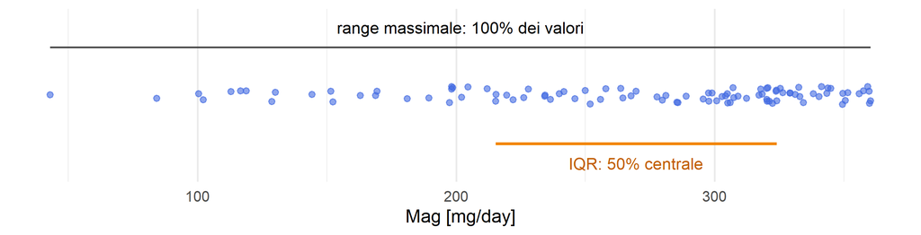

## Sondaggio

Per me: [Percentili](https://app.wooclap.com/events/STATMEDPERCENTILI/0)

Per voi:

[figure not shown]

bit.ly/statmed-sondaggio-percentili

## Accorpamenti

La struttura generale dei dati raggruppati è simile a

| Gruppi | Punto medio $m_i$ | Frequenza | Frequenza relativa |
| --- | --- | --- | --- |
| $[y_1, y_2)$ | $\frac{y_1+y_2}{2}$ | $f_1$ | $f_1/n$ |
| $\vdots$ | $\vdots$ | $\vdots$ | $\vdots$ |
| $[y_k, y_{k+1})$ | $\frac{y_k+y_{k+1}}{2}$ | $f_k$ | $f_k/n$ |

- **frequenza** (assoluta) $f_i$: quante osservazioni cadono nel gruppo $i$;
- **frequenza relativa** $f_i/n$: la loro proporzione sul totale $n$. Le frequenze relative sommano a 1.

## Accorpamenti: Epic - magnesio

Intake giornaliero di magnesio (mg/day) per $n = 100$ soggetti

```
43, 84.2, 100.4, 102.2, 113, 116.7, 118.9, 128.8, 130.1, 144.3, 151.5,
152.3, 163, 168.9, 169.4, 181.1, 189.5, 197.5, 198.3, 198.3, 198.7, 202.2,
204.6, 212, 215.3, 215.4, 219.6, 222, 226.2, 228, 234.3, 234.4, 236.4,
239.9, 241.7, 245.9, 250, 251.8, 255.8, 257.9, 263.7, 264.5, 267.7, 269.6,
277.7, 279.7, 281.1, 285.3, 285.8, 288.9, 295.5, 297.6, 297.8, 299, 300.8,
302.9, 304.2, 304.9, 305.1, 306, 307.1, 307.4, 309, 312.3, 317.1, 317.8,
318.4, 320.1, 320.2, 320.4, 320.5, 321.1, 322.4, 323.7, 323.9, 324, 325.3,
326.4, 329.1, 329.2, 331.1, 332.6, 333, 334.3, 338.1, 340.3, 341.3, 343.4,
343.8, 344.9, 349.4, 349.6, 350.5, 351.4, 355.9, 357.6, 359.1, 359.8, 359.8,
360.3
```

## Accorpamenti: Epic - magnesio

Accorpati in 8 gruppi con approssimativamente la stessa quantità di soggetti in ciascun gruppo:

| Gruppi | m | Freq | Freq. relativa |
| --- | --- | --- | --- |
| [ 43.0,168.9) | 105.95 | 13 | 0.13 |
| [168.9,215.4) | 192.15 | 12 | 0.12 |
| [215.4,255.8) | 235.60 | 13 | 0.13 |
| [255.8,295.5) | 275.65 | 12 | 0.12 |
| [295.5,312.3) | 303.90 | 13 | 0.13 |
| [312.3,324.0) | 318.15 | 12 | 0.12 |
| [324.0,343.8) | 333.90 | 13 | 0.13 |
| [343.8,360.3] | 352.05 | 12 | 0.12 |

## misure ponderate: media aritmetica ponderata

La media aritmetica campionaria ponderata è pari a
$$\bar{x}_g = \frac{\sum_{i=1}^k f_im_i}{\sum_{i=1}^k f_i}$$

Per il dataset accorpato sui dati di magnesio, è pari a
$$\bar{x}_g = \frac{13(105.95)+\ldots+12(352.05)}{13+\ldots+12}= 26387.55/100 = 263.8755$$

## Mappa: Localizzazione

- Mappa
- Indice

```
%%{init: {"htmlLabels": false, "flowchart": {"padding": 12, "wrappingWidth": 320}, "themeVariables": {"fontFamily": "Arial, Helvetica, sans-serif"}}}%%
flowchart LR
  n_sommatoria["Sommatoria Σ"]:::prev
  n_variabile_continua["Continua"]:::prev
  n_variabile_discreta["Discreta"]:::prev
  n_misura_di_centralita["Misura di centralità"]:::cur
  n_campione["Campione"]:::cur
  n_media_aritmetica["Media"]:::cur
  n_media_sensibile_ai_valori_estremi["Media e valori estremi"]:::cur
  n_mediana["Mediana"]:::cur
  n_mediana_robusta_ai_valori_estremi["Mediana e valori estremi"]:::cur
  n_media_o_mediana["Media o mediana?"]:::cur
  n_frequenza_assoluta["Frequenza"]:::cur
  n_moda["Moda"]:::cur
  n_misura_di_variabilita["Misura di variabilità"]:::cur
  n_range["Range"]:::cur
  n_varianza["Varianza"]:::cur
  n_deviazione_standard["Deviazione standard"]:::cur
  n_somma_degli_scarti_nulla["Scarti a somma zero"]:::cur
  n_formula_computazionale_della_varianza["Varianza: formula alternativa"]:::cur
  n_coefficiente_di_variazione["Coefficiente di variazione"]:::cur
  n_cv_invariante_per_scala["CV e unità di misura"]:::cur
  n_percentile["Percentile"]:::cur
  n_quartile["Quartile"]:::cur
  n_accorpamento_in_classi["Classi"]:::cur
  n_frequenza_relativa["Frequenza relativa"]:::cur
  n_media_ponderata["Media ponderata"]:::cur
  n_distanza_interquartile["Distanza interquartile"]:::cur
  n_accorpamento_in_classi --> n_media_ponderata
  n_campione --> n_media_aritmetica
  n_coefficiente_di_variazione --> n_cv_invariante_per_scala
  n_deviazione_standard --> n_coefficiente_di_variazione
  n_frequenza_assoluta --> n_accorpamento_in_classi
  n_frequenza_assoluta --> n_frequenza_relativa
  n_frequenza_assoluta --> n_moda
  n_media_aritmetica --> n_media_ponderata
  n_media_aritmetica --> n_media_sensibile_ai_valori_estremi
  n_media_aritmetica --> n_mediana
  n_media_aritmetica --> n_misura_di_variabilita
  n_media_aritmetica --> n_somma_degli_scarti_nulla
  n_media_sensibile_ai_valori_estremi --> n_mediana_robusta_ai_valori_estremi
  n_mediana --> n_media_o_mediana
  n_mediana --> n_mediana_robusta_ai_valori_estremi
  n_mediana --> n_percentile
  n_misura_di_variabilita --> n_range
  n_misura_di_variabilita --> n_varianza
  n_percentile --> n_quartile
  n_quartile --> n_distanza_interquartile
  n_range --> n_distanza_interquartile
  n_sommatoria --> n_media_aritmetica
  n_variabile_continua --> n_accorpamento_in_classi
  n_variabile_continua --> n_media_aritmetica
  n_variabile_continua --> n_misura_di_centralita
  n_variabile_discreta --> n_frequenza_assoluta
  n_varianza --> n_deviazione_standard
  n_varianza --> n_formula_computazionale_della_varianza
  classDef cur fill:#e6f0fa,stroke:#035AA6,color:#000000
  classDef prev fill:#f4f4f4,stroke:#9a9a9a,color:#555555,stroke-dasharray:4 3
  classDef opt fill:#ffffff,stroke:#035AA6,color:#555555,stroke-dasharray:2 2
```

Ogni freccia va da un concetto a quelli che lo usano. In grigio i concetti delle sezioni o dei deck precedenti (con il numero del deck).

- Misura di centralità
- Campione
- Media
- Media e valori estremi
- Mediana
- Mediana e valori estremi
- Media o mediana?
- Frequenza
- Moda
- Misura di variabilità
- Range
- Varianza
- Deviazione standard
- Scarti a somma zero
- Varianza: formula alternativa
- Coefficiente di variazione
- CV e unità di misura
- Percentile
- Quartile
- Classi
- Frequenza relativa
- Media ponderata
- Distanza interquartile

## **Rappresentazione**

#### **Dati continui**

- Istogrammi
- Box-plot

#### **Dati discreti**

- Grafici a barre

## Istogramma

L’istogramma è uno stimatore della distribuzione

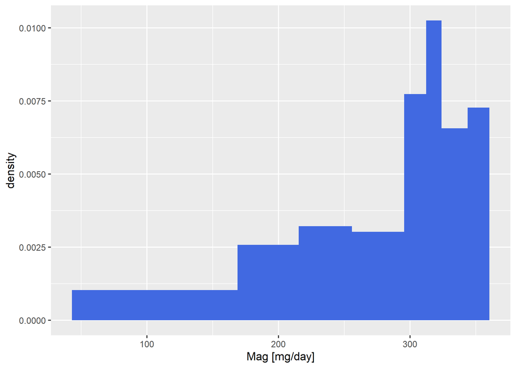

## Dati continui: istogramma

Per il calcolo dell’istogramma, la tabella delle frequenze deve essere estesa

| Gruppi | Punto medio $m_i$ | Frequenza | Ampiezza | Densità |
| --- | --- | --- | --- | --- |
| $[y_1, y_2)$ | $\frac{y_1+y_2}{2}$ | $f_1$ | $a_1 = y_2-y_1$ | $\frac{f_1}{n*a_1}$ |
| $\vdots$ | $\vdots$ | $\vdots$ | $\vdots$ | $\vdots$ |
| $[y_k, y_{k+1})$ | $\frac{y_k+y_{k+1}}{2}$ | $f_k$ | $a_k = y_{k+1}-y_k$ | $\frac{f_k}{n*a_k}$ |

La densità è la frequenza relativa divisa per l’ampiezza: l’area di ogni barra è la frequenza relativa del suo gruppo, e l’area totale dell’istogramma è 1.

## Istogramma: tabella e grafico

| Gruppo | $m_i$ | $f_i$ | $f_i/n$ | $a_i$ | Densità |
| --- | --- | --- | --- | --- | --- |
| [ 43.0,168.9) | 105.95 | 13 | 0.13 | 125.9 | 0.0010 |
| [168.9,215.4) | 192.15 | 12 | 0.12 | 46.5 | 0.0026 |
| [215.4,255.8) | 235.60 | 13 | 0.13 | 40.4 | 0.0032 |
| [255.8,295.5) | 275.65 | 12 | 0.12 | 39.7 | 0.0030 |
| [295.5,312.3) | 303.90 | 13 | 0.13 | 16.8 | 0.0077 |
| [312.3,324.0) | 318.15 | 12 | 0.12 | 11.7 | 0.0103 |
| [324.0,343.8) | 333.90 | 13 | 0.13 | 19.8 | 0.0066 |
| [343.8,360.3] | 352.05 | 12 | 0.12 | 16.5 | 0.0073 |

- Frequenze
- Densità

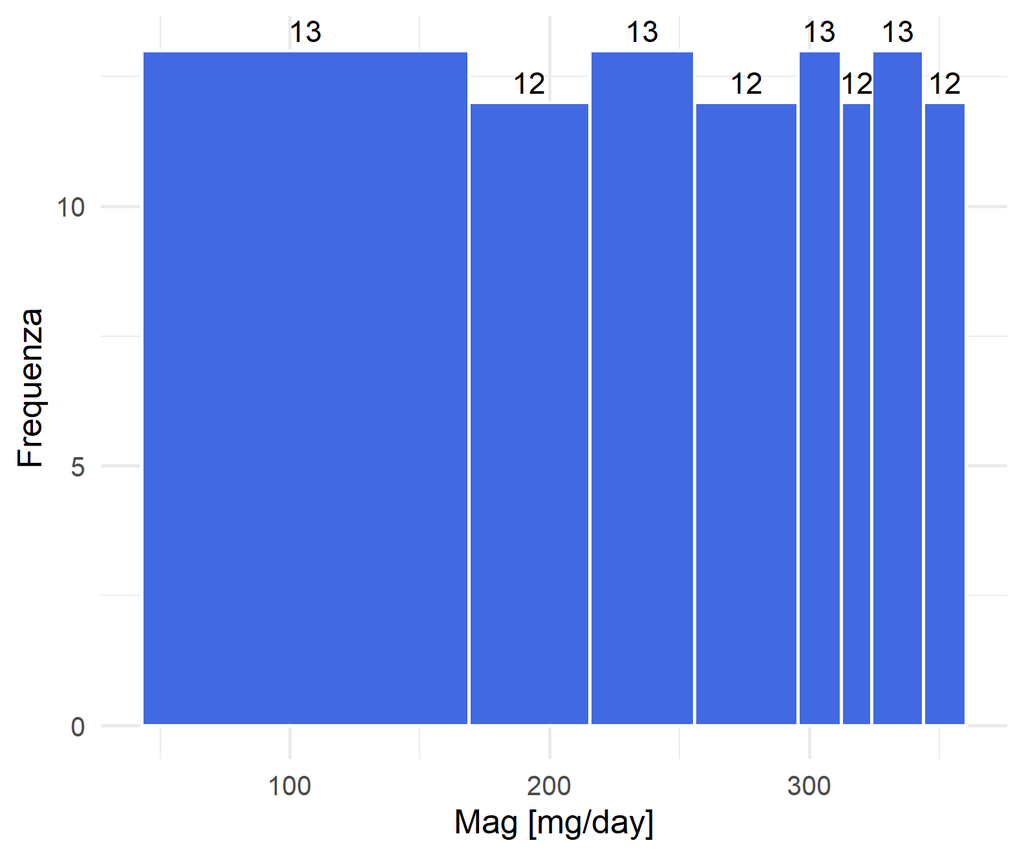

Altezza = frequenza: i gruppi larghi sembrano pesare di più.

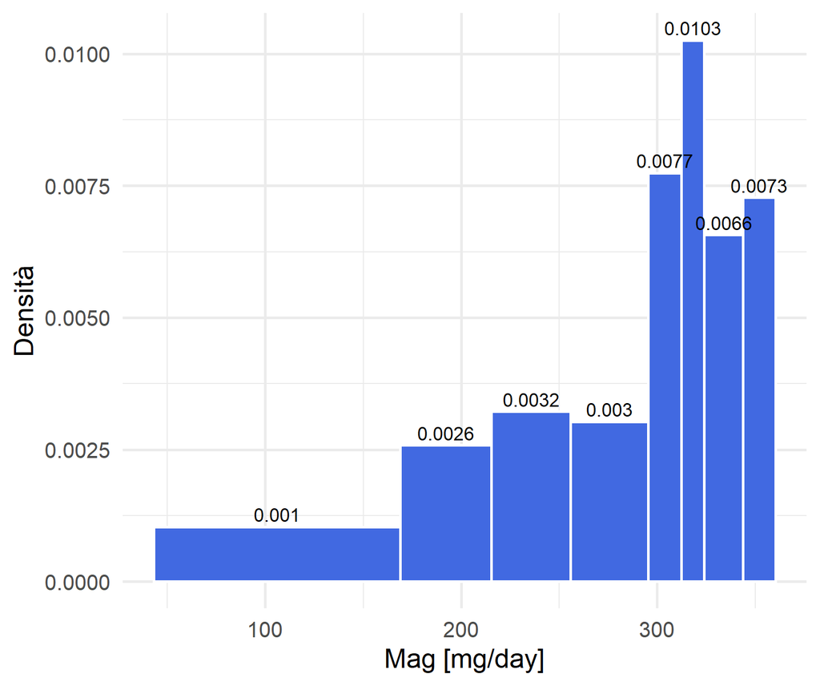

Altezza = densità: l’area di ogni barra è la frequenza relativa.

## Istogramma: autocalcolato

Se ampiezze tutte uguali, la *forma* standardizzata ad area unitaria è proporzionale a quella con barre di altezza le frequenze

- Count
- Hist

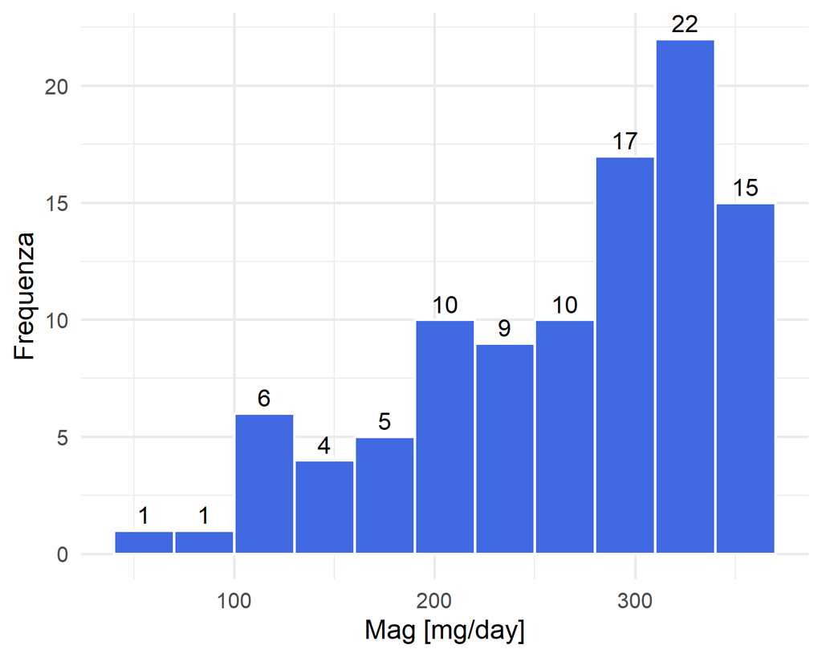

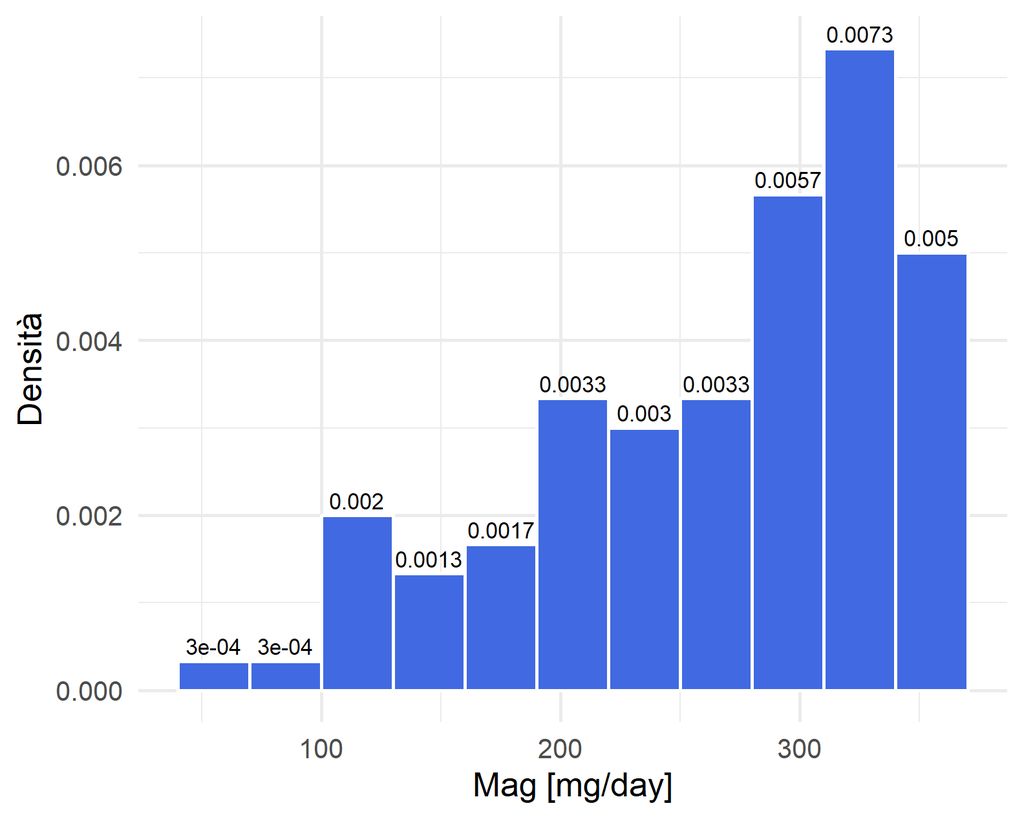

| Gruppo | $m_i$ | $f_i$ | $f_i/n$ | $a_i$ | Densità |
| --- | --- | --- | --- | --- | --- |
| [40, 70) | 55 | 1 | 0.01 | 30 | 0.0003 |
| [70, 100) | 85 | 1 | 0.01 | 30 | 0.0003 |
| [100, 130) | 115 | 6 | 0.06 | 30 | 0.0020 |
| [130, 160) | 145 | 4 | 0.04 | 30 | 0.0013 |
| [160, 190) | 175 | 5 | 0.05 | 30 | 0.0017 |
| [190, 220) | 205 | 10 | 0.10 | 30 | 0.0033 |
| [220, 250) | 235 | 9 | 0.09 | 30 | 0.0030 |
| [250, 280) | 265 | 10 | 0.10 | 30 | 0.0033 |
| [280, 310) | 295 | 17 | 0.17 | 30 | 0.0057 |
| [310, 340) | 325 | 22 | 0.22 | 30 | 0.0073 |
| [340, 370) | 355 | 15 | 0.15 | 30 | 0.0050 |

## Boxplot (general)

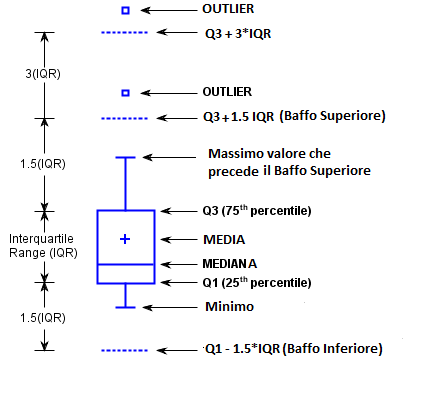

## Dati continui: box-plot

Il box-plot è un modo per rappresentare graficamente una distribuzione rispetto a **centralità e variabilità**. Per un campione di ampiezza $n$

- Il segmento all’interno del box è la mediana.
- il **primo quartile** (h, o 25º percentile) è il bordo inferiore della scatola (box)
- il **terzo quartile** (H, o 75º percentile) è il bordo superiore della scatola
- l’ampiezza della scatola (box) è il **Range Inter-Quartile (IQR)**, ovvero la differenza tra il III e il I quartile ($H - h$).
- i **baffi** arrivano fino al valore più lontano dalla scatola ma entro una volta e mezza l’IQR dai suoi bordi; i limiti $h - 1.5 \times (H-h)$ e $H + 1.5 \times (H-h)$ sono il baffo inferiore e superiore dello schema
- un **valore estremo** è: un valore oltre i baffi, cioè che si allontana dai bordi della scatola più di una volta e mezza l’IQR, cioè
  $$x > H + 1.5 \times (H-h) \quad o \quad x < h - 1.5 \times (H-h)$$
- un **valore anomalo** è: un valore che si allontana dai bordi della scatola più di tre volte l’IQR, cioè
  $$x > H + 3 \times (H-h) \quad o \quad x < h - 3 \times (H-h)$$

## Box-plot (calcolo)

Un’assunzione giornaliera di 43 mg/die di magnesio rappresenta un valore estremo

```
  [1]  43.0  84.2 100.4 102.2 113.0 116.7 118.9 128.8 130.1
 [10] 144.3 151.5 152.3 163.0 168.9 169.4 181.1 189.5 197.5
 [19] 198.3 198.3 198.7 202.2 204.6 212.0 215.3 215.4 219.6
 [28] 222.0 226.2 228.0 234.3 234.4 236.4 239.9 241.7 245.9
 [37] 250.0 251.8 255.8 257.9 263.7 264.5 267.7 269.6 277.7
 [46] 279.7 281.1 285.3 285.8 288.9 295.5 297.6 297.8 299.0
 [55] 300.8 302.9 304.2 304.9 305.1 306.0 307.1 307.4 309.0
 [64] 312.3 317.1 317.8 318.4 320.1 320.2 320.4 320.5 321.1
 [73] 322.4 323.7 323.9 324.0 325.3 326.4 329.1 329.2 331.1
 [82] 332.6 333.0 334.3 338.1 340.3 341.3 343.4 343.8 344.9
 [91] 349.4 349.6 350.5 351.4 355.9 357.6 359.1 359.8 359.8
[100] 360.3
```

- $h$ è la media tra l’osservazione $(100 * 1/4)$ª e la $((100 * 1/4) + 1)$ª, ovvero $(215.3+215.4) / 2 = 215.35$
- $H$ è la media dell’osservazione $(100 * 3/4)$ª e la $((100 * 3/4) + 1)$ª, ovvero $(323.9+324) / 2 = 323.95$
- i limiti per i valori estremi sono quindi:
  $$x > 323.95 + 1.5 * (323.95 - 215.35) = 486.85$$
  $$x < 215.35 - 1.5 * (323.95 - 215.35) = 52.45$$
- i valori anomali sarebbero:
  $$x > 323.95 + 3 * (323.95 - 215.35) = 649.75$$
  $$x < 215.35 - 3 * (323.95 - 215.35) = -110.45$$
  (valore negativo: un’assunzione non può essere negativa, quindi nessun valore anomalo inferiore)

## Box-plot (il grafico)

Il box-plot dei 100 valori di magnesio, con quartili e limiti calcolati come sopra (la regola dei percentili vista a lezione)

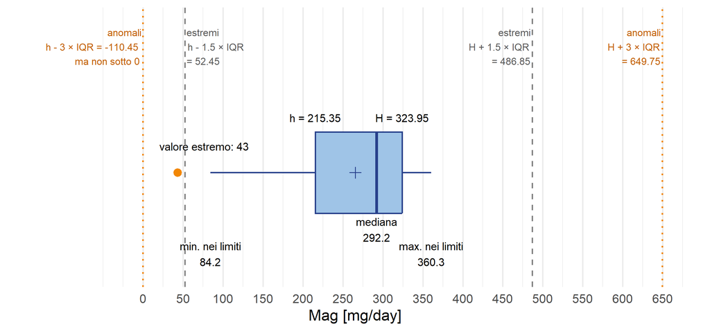

La croce è la media (265.53). Tratteggiati i limiti per i valori estremi, punteggiati quelli per i valori anomali. Il magnesio assunto è una quantità e non può essere negativo: il limite inferiore per gli anomali ($-110.45$) si ferma a 0, quindi sotto non ci sono anomali possibili; sopra, nessun valore supera 649.75.

## Box-plot e istogramma

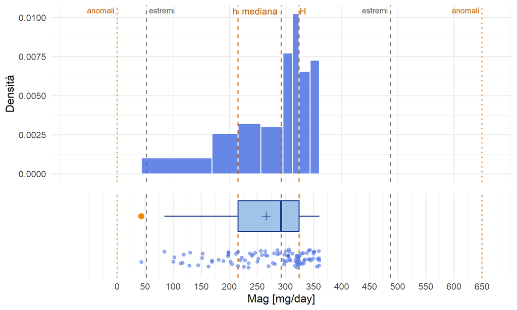

Ogni pezzo del box-plot contiene un quarto dei dati: stretto dove i dati sono fitti (istogramma alto), largo dove sono radi. Il baffo sinistro e il 43 sono la coda bassa a sinistra. Sotto la scatola i 100 valori, la croce è la media; tratteggiate grigie le soglie per gli estremi, punteggiate arancio quelle per gli anomali.

## Dati discreti: barre

Volendo rappresentare confronti tra conteggi, possiamo usare grafici a barre: ciascuna barra è il conteggio di un valore di una variabile discreta (nominale, ordinale, dicotomica, o cardinale con pochi valori).

> ATTENZIONE 1: per una variabile continua si usa l’istogramma, che ne rappresenta la distribuzione; per una variabile discreta si usa il grafico a barre, che rappresenta i conteggi dei suoi valori!

> ATTENZIONE 2: in un grafico a barre, la base delle barre DEVE essere sempre (ben!!) definita, ovvero deve SEMPRE iniziare dall’opportuno “zero” (per esempio da 1 per scale logaritmiche, da 0 per i conteggi classici)

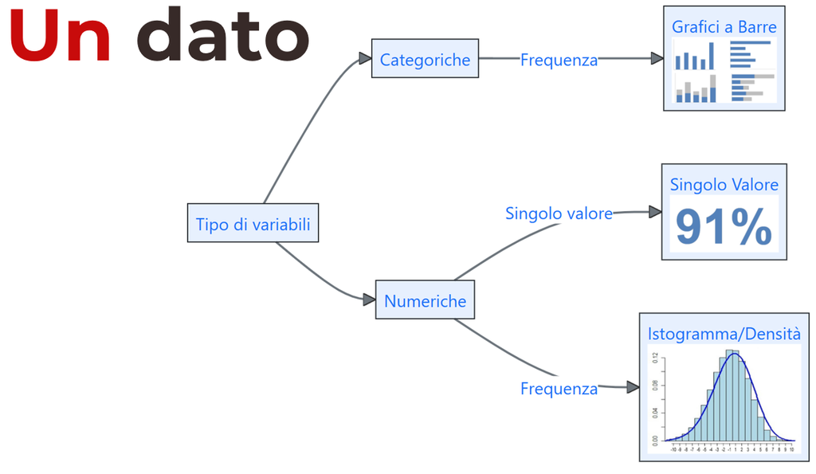

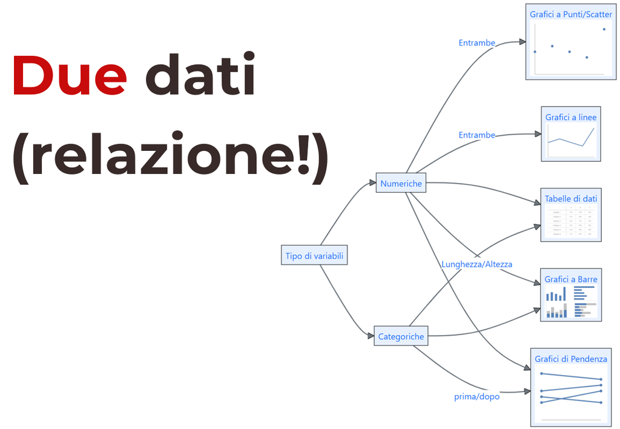

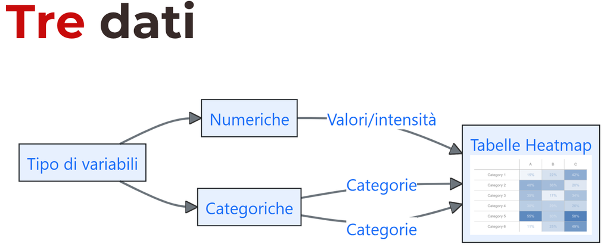

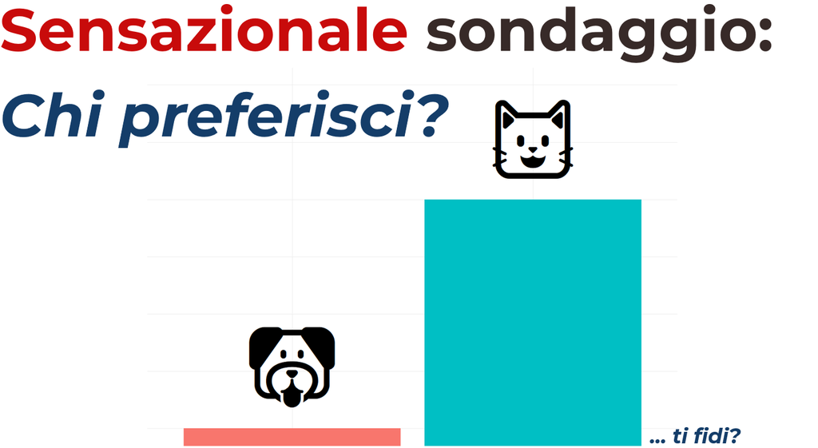

[figure not shown]

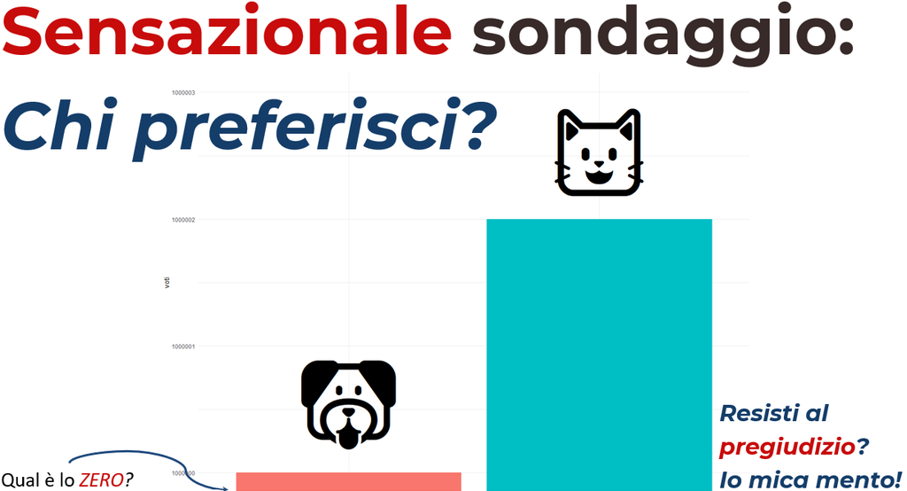

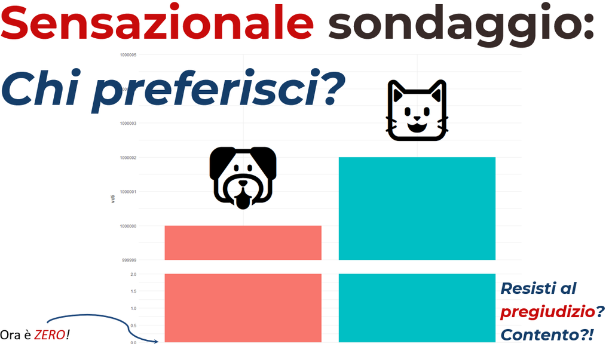

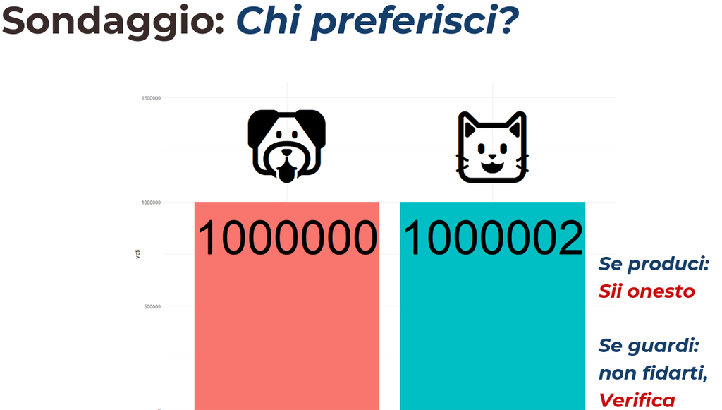

## Prima

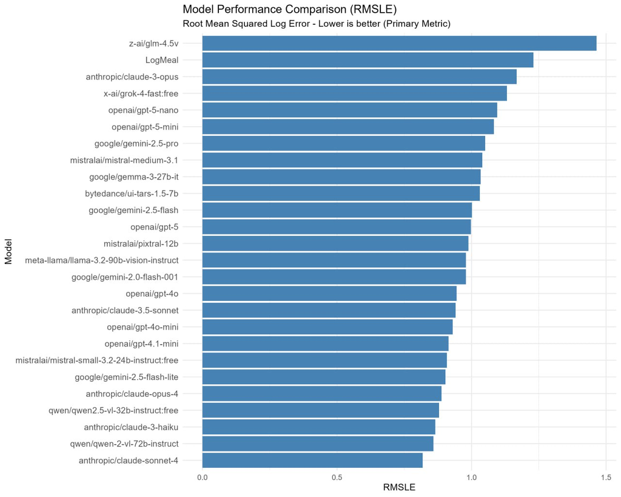

## Prima

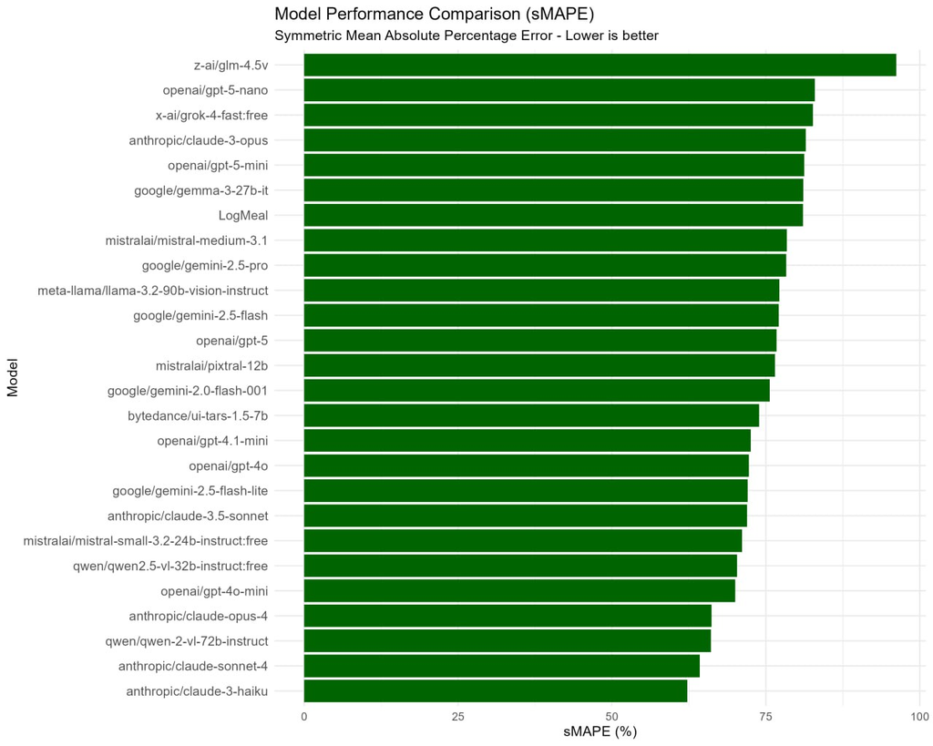

## Prima

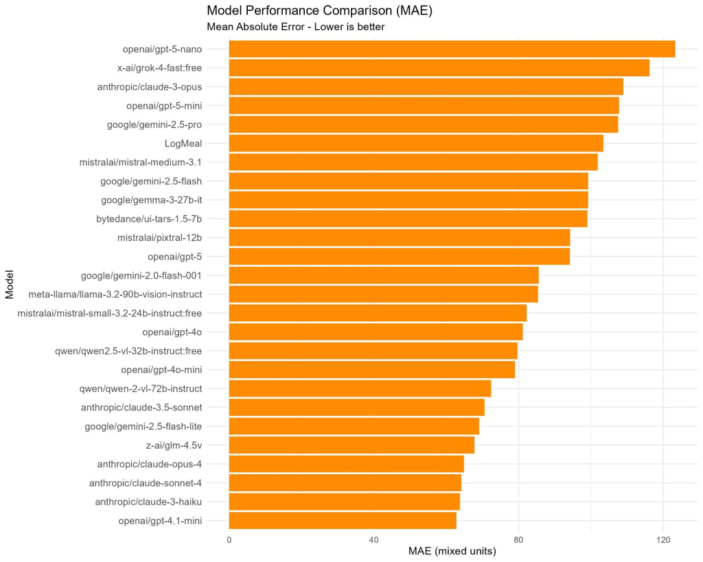